# Is Parenthood Worth Repeating? A Dyadic Latent Growth Curve Study of Parenthood Regret and Family Expansion Intentions

Author

Julia Idzikowska, Patrycja Osiecka, Jakub Duras, Konrad Piotrowski

**Main finding:** Higher initial intentions to have another child were linked to lower initial parenthood regret, and declines in these intentions co-occurred with increases in regret over time.

**Aim**

The aim of the study was to examine whether **parenthood regret** and **family expansion intentions** are linked across the transition to parenthood.

More specifically, the study asked whether these constructs are associated:

1. at the level of **initial status**,
2. at the level of **linear developmental change**,
3. within mothers and fathers separately,
4. and across partners within couples.

**Core theoretical idea:** family expansion intentions may be more than reproductive plans. They may also indicate whether parenthood is experienced as an identity-relevant experience worth repeating.

**Why family expansion intentions matter theoretically**

Intentions to have another child are not only about future reproductive planning. In the context of parenthood regret, they may also reflect whether the experience of parenthood is evaluated as something one would be willing to repeat.

**Why parenthood regret is not only “regret about a past decision”**

Parenthood is irreversible and identity-defining. For that reason, parenthood regret may involve more than dissatisfaction with a past choice. It may also reflect ongoing reconsideration of oneself as a parent.

**Background**

Parenthood regret is often conceptualized as a **counterfactual, decision-related emotion**: the feeling that, if it were possible to return to the past, one would choose not to become a parent (Piotrowski, Roskam, and Mikolajczak 2026).

However, because parenthood is an irreversible and identity-defining life transition, regret may also be understood as a form of **ongoing reconsideration of parental identity**.

From this perspective, family expansion intentions become theoretically informative. The perceived probability of having another child may reflect not only reproductive plans, but also whether parenthood is experienced as **worth repeating**.

The conceptual distinction matters: this study does not treat family expansion intentions as a simple behavioral plan. It treats them as a psychologically meaningful indicator of how parenthood is evaluated during the transition to parenting.

**Methods**

**Design:** longitudinal dyadic study  
**Sample:** 234 Polish couples  
**Measurement waves:** seven waves from pregnancy into the first year of parenthood  
**Analytic model:** Dyadic Latent Growth Curve Model

Intercept represents **initial level**, whereas slope represents **linear change over time**.

Figure 1 presents the full 7-wave dyadic latent growth curve model.

### Measures

**Parenthood regret** was operationalized using the reconsideration dimension of the Utrecht-Management of Identity Commitments Scale adapted to the parenting domain (Piotrowski 2018).

**Family expansion intentions** were measured as the perceived probability of having another child, rated on a 0–100 scale. Higher scores indicated a greater perceived likelihood of future family expansion.

### Analytic strategy

The D-LGCM estimated latent **intercepts** and **slopes** for both constructs, separately for mothers and fathers.

**Intercept** = initial level of the construct  
**Slope** = linear change over time

The model tested associations between:

- mothers’ family expansion intentions and mothers’ parenthood regret,
- fathers’ family expansion intentions and fathers’ parenthood regret,
- mothers’ and fathers’ initial levels,
- mothers’ and fathers’ changes over time.

### Model fit

χ²(320) = 527.826  
CFI = .964  
RMSEA = .053  
SRMR = .064

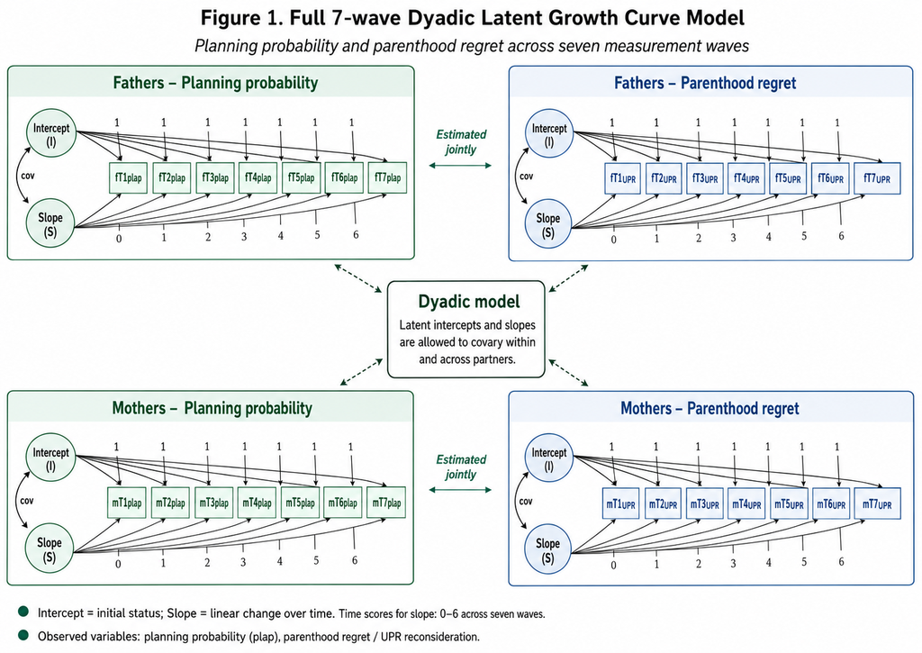

Figure 1: Full 7-wave dyadic latent growth curve model. Intercept represents initial status; slope represents linear change over time.

**Results**

### Mean-level change

**Family expansion intentions decreased over time among fathers**,  
*B* = -1.28, *p* < .001.

Among mothers, the change was not statistically significant,  
*B* = -0.22, *p* = .363.

**Parenthood regret showed no significant mean linear change** among women,  
*B* = -0.007, *p* = .355,  
or men,  
*B* = 0.006, *p* = .411.

### Initial levels

Higher initial family expansion intentions were associated with lower initial parenthood regret among both women and men.

Women: *B* = -6.27, *p* < .001  
Men: *B* = -5.99, *p* < .001

### Linked developmental trajectories

Declines in family expansion intentions co-occurred with increases in parenthood regret among both women and men.

Women: *B* = -0.082, *p* = .024  
Men: *B* = -0.058, *p* = .037

### Dyadic associations

Initial family expansion intentions were positively associated across partners.

Partner similarity in initial family expansion intentions:  
*B* = 546.22, *p* < .001

Changes in family expansion intentions were also positively associated across partners.

Partner similarity in change in family expansion intentions:  
*B* = 4.82, *p* < .001

Cross-partner associations were also observed between one partner’s initial family expansion intentions and the other partner’s initial parenthood regret.

Women’s intentions ↔︎ men’s regret: *B* = -2.68, *p* = .034  
Men’s intentions ↔︎ women’s regret: *B* = -3.55, *p* = .023

**Discussion**

### Mothers

Family expansion intentions  
Intercept

↔︎  
*B* = -6.27, *p* < .001

Parenthood regret  
Intercept

Family expansion intentions  
Slope

↔︎  
*B* = -0.082, *p* = .024

Parenthood regret  
Slope

### Dyadic level

**Initial family expansion intentions aligned across partners**  
*B* = 546.22, *p* < .001

**Change in family expansion intentions aligned across partners**  
*B* = 4.82, *p* < .001

**Cross-partner initial associations**

Women’s intentions ↔︎ men’s regret:  
*B* = -2.68, *p* = .034

Men’s intentions ↔︎ women’s regret:  
*B* = -3.55, *p* = .023

### Fathers

Family expansion intentions  
Intercept

↔︎  
*B* = -5.99, *p* < .001

Parenthood regret  
Intercept

Family expansion intentions  
Slope

↔︎  
*B* = -0.058, *p* = .037

Parenthood regret  
Slope

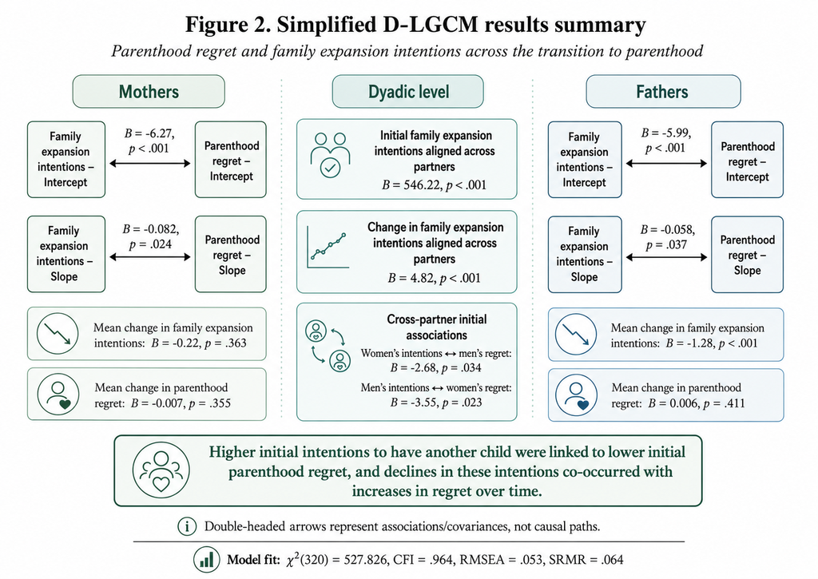

Figure 2: Simplified D-LGCM results summary. Double-headed arrows represent associations/covariances, not causal paths.

## Interpretation

The findings suggest that parenthood regret and family expansion intentions are linked across the transition to parenthood at both the level of **initial status** and **developmental change**.

Parents who initially reported stronger intentions to have another child also reported lower initial parenthood regret. Moreover, decreases in family expansion intentions co-occurred with increases in parenthood regret over time.

**Substantive interpretation:** family expansion intentions may function as an identity-relevant indicator of whether parenthood is experienced as worth repeating.

**Methodological caution:** the D-LGCM supports developmental coupling, not causal prediction. The model does not show that declining family expansion intentions cause parenthood regret. It shows that the trajectories of these two processes move together in a theoretically meaningful way.

**TAKEAWAY**

Family expansion intentions and parenthood regret appear to be developmentally coupled during the transition to parenthood, and this coupling unfolds within the dyadic context of the couple.

## References

Piotrowski, Konrad. 2018. “Adaptation of the Utrecht-Management of Identity Commitments Scale (u-MICS) to the Measurement of the Parental Identity Domain.” *Scandinavian Journal of Psychology* 59 (2): 157–66. https://doi.org/10.1111/sjop.12416.

Piotrowski, Konrad, Isabelle Roskam, and Moira Mikolajczak. 2026. “A Decade of Research on Parenthood Regret.” *Trends in Cognitive Sciences*. https://doi.org/10.1016/j.tics.2026.02.004.